# ABC7 WABC New York Vaccine Tracker

The ABC7 Vaccine Tracker shows that about **14.8 million** people across New York are fully vaccinated against COVID-19 as of Mar. 15. About **17.4 million** people statewide have received at least one dose.

Statewide, ABC7's analysis shows the number of people fully vaccinated is about **75.9%** of all New York residents.

| Fully vaccinated as a percentage of entire population |
| --- |
| 75.9 |

The data shows the share of New York residents 12 or over who are now fully vaccinated is about **84.8%**. In May, the federal government approved the first vaccines for people ages 12-15, but it remains unavailable to children under 12.

| Fully vaccinated as a percentage of everyone 12 and older |
| --- |
| 84.8 |

You can search every vaccine provider with shots available today in New York in our searchable map below.

## How is New York doing getting everyone vaccinated?

The pace of vaccinations has slowed. Over the last seven days, the data shows an average of **4,081** people per day became fully vaccinated, compared to **5,212** people per day the seven days before that. That's a change of **-21.7%**.

You can see the percentage of all people vaccinated day-by-day in the chart below.

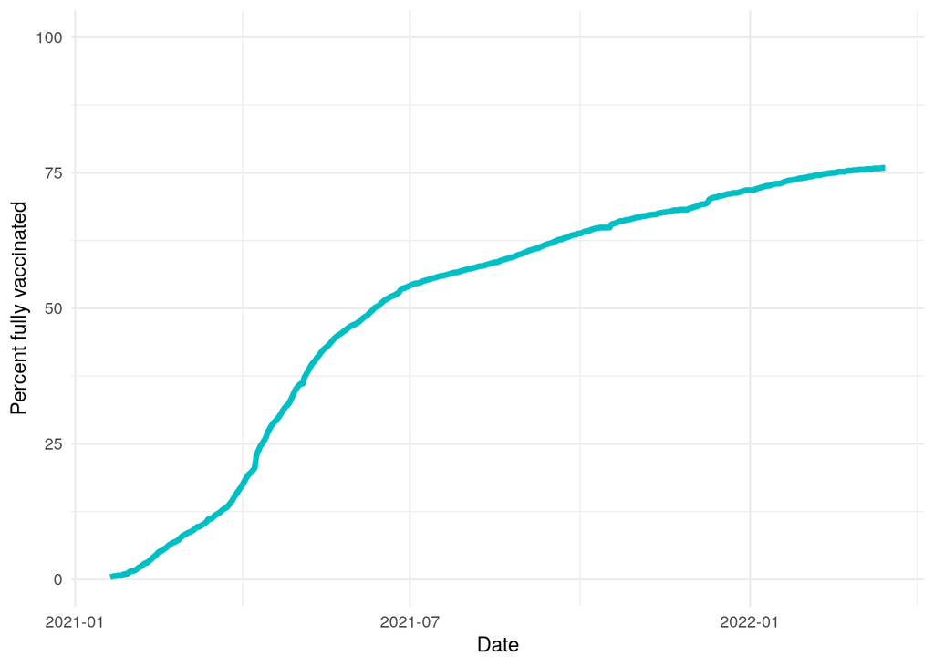

The CDC data is updated daily, but the agency says its total number of vaccinations could be behind actual doses administered by up to 72 hours based on when it receives data from state and local health departments.

## What's happening in my New York county?

You can look up the progress thus far in **every New York county** below. Start typing your county name in the search bar to find it faster. These county totals, from the CDC, include doses from state and federal government providers and only include the county's residents.

| County | Fully vaccinated | % of entire population | % of people 12 and over |
| --- | --- | --- | --- |
| Albany County | 226223 | 74 | 80.3 |
| Allegany County | 20258 | 44 | 48.9 |
| Bronx County | 1046873 | 73.8 | 85.1 |
| Broome County | 120488 | 63.3 | 70.1 |
| Cattaraugus County | 42548 | 55.9 | 63 |
| Cayuga County | 45053 | 58.8 | 65.1 |
| Chautauqua County | 74605 | 58.8 | 65.5 |
| Chemung County | 49683 | 59.5 | 66.6 |
| Chenango County | 28655 | 60.7 | 68.1 |
| Clinton County | 58058 | 72.1 | 78.6 |

[output cut: 52 more lines]

## If I am eligible, where can I get vaccinated?

At least **2,910** pharmacies, medical facilities and other providers have vaccines in stock across New York. You can **search all of them in our live map**, which pulls data every morning from the VaccineFinder system at the CDC's vaccines.gov.

The yellow and green circles show clusters of locations. If you click them, the map will zoom in to show individual locations. Clicking a red marker will show the vaccine location's name, address and ways to get more information online or by phone.

You can use the search button at top right to zoom to your address or zip code.

[interactive chart not shown]

Source: VaccineFinder, Boston Children's Hospital. Data ©2021. Boston Children’s Hospital. All rights reserved.

If you want to learn more about how state officials are administering vaccines, you can [click here](https://covid19.ncdhhs.gov/vaccines) (or scroll to the bottom to see a link) to learn more about the state's vaccination strategy.